## Tarea 1

Programa Experto en Inteligencia Artificial con Python  
ML3000 - Modelos Analíticos Avanzados  
Estudiante: Natalia Bonilla Villalobos.  
**Aprendizaje Supervisado Clasificación Bayesiana (Método Naïve (ingenuo) de Bayes)**

# Menú

- Ejercicio 1
- Ejercicio 2
- Ejercicio 3

# Ejercicio 1

[40 puntos] En este ejercicio vamos a trabajar con los datos `hotel_bookings_v1.csv`. Este conjunto de datos contiene información de reserva para un hotel urbano y un hotel resort, e incluye información como cuándo se realizó la reserva, la duración de la estadía, la cantidad de adultos, niños y/o bebés, y la cantidad de espacios de estacionamiento disponibles. entre otras cosas.

- `hotel`: Tipo de hotel. (Categórica)
- `lead_time`: Número de días entre la fecha de entrada de la reserva y la fecha de llegada.(Numérica)
- `arrival_date_month`: Mes de fecha de llegada. (Categórica)
- `stays_in_weekend_nights`: Número de noches de fin de semana. (Numérica)
- `stays_in_week_nights`: Número de noches entre semana. (Numérica)
- `adults`: Número de Adultos. (Numérica)
- `children`: Número de ni~nas y ni~nos. (Numérica)
- `babies`: Número de bebés. (Numérica)
- `previous_cancellations`: Cancelaciones previas.(Numérica)
- `previous_bookings_not_canceled`: Reservaciones previas no canceladas.(Numérica)
- `assigned_room_type`: Código del tipo de habitación asignado a la reserva.(Categórica)
- `booking_changes`: Cambios/modificaciones realizados en la reserva. (Numérica)
- `deposit_type`: Indica si se realizó un depósito para garantizar la reserva. (Categórica)
- `days_in_waiting_list`: Días en lista de espera. (Numérica)
- `customer_type`: Tipo de reserva. (Categórica)
- `adr`: Tarifa diaria promedio. (Numérica)
- `required_car_parking_spaces`: Espacios de parqueo requeridas. (Numérica)
- `total_of_special_requests`: Solicitudes especiales realizadas. (Numérica)
- `is_canceled`: Indica si se canceló la reservación o no. (Variable a predecir).

Realice lo siguiente:

- a) Use los métodos de Bayes, Discriminante Lineal y Cuadrático en Python para generar modelos predictivos para la tabla `hotel_bookings_v1.csv` usando el 90% de los datos para la tabla aprendizaje y un 10% para la tabla testing. Obtenga los índices de precisión e interprete los resultados.
- b) Genere también todos los modelos vistos en cursos anteriores.
- c) Construya un DataFrame que compare todos los modelos generados. Para esto en cada una de las filas debe aparecer el nombre del modelo predictivo y en las columnas deben aparecer los índices `Precisión Global`, `Error Global`, `Precisión Positiva (PP)` y `Precisión Negativa (PN)`. Cuál de los modelos es mejor para estos datos?

↑ Volver al Menú

```python
import numpy as np
import pandas as pd
import seaborn as sns
import matplotlib.pyplot as plt
from matplotlib import colors as mcolors
from sklearn.metrics import accuracy_score
from sklearn.metrics import confusion_matrix
from sklearn.model_selection import train_test_split
from sklearn.pipeline import Pipeline
from sklearn.compose import ColumnTransformer
from sklearn.preprocessing import OneHotEncoder, StandardScaler

from sklearn.tree import DecisionTreeClassifier
from sklearn.ensemble import RandomForestClassifier
from sklearn.ensemble import AdaBoostClassifier
from sklearn.ensemble import GradientBoostingClassifier
# import xgboost as xgb

from sklearn.naive_bayes import GaussianNB
from sklearn.discriminant_analysis import LinearDiscriminantAnalysis
from sklearn.discriminant_analysis import QuadraticDiscriminantAnalysis

from sklearn.svm import SVC
from sklearn.neighbors import KNeighborsClassifier
from xgboost import XGBClassifier
from sklearn.preprocessing import LabelEncoder
```

## **Carga de Datos**

```python
df = pd.read_csv("../../hotel_bookings_v1.csv")
df.head(3)
```

|  | hotel | is_canceled | lead_time | arrival_date_month | stays_in_weekend_nights | stays_in_week_nights | adults | children | babies | previous_cancellations | previous_bookings_not_canceled | assigned_room_type | booking_changes | deposit_type | days_in_waiting_list | customer_type | adr | required_car_parking_spaces | total_of_special_requests |
| --- | --- | --- | --- | --- | --- | --- | --- | --- | --- | --- | --- | --- | --- | --- | --- | --- | --- | --- | --- |
| 0 | Resort Hotel | Yes | 74 | January | 1 | 0 | 2 | 0 | 0 | 0 | 0 | A | 0 | No Deposit | 0 | Transient | 57.6 | 0 | 0 |
| 1 | Resort Hotel | Yes | 62 | January | 2 | 2 | 2 | 0 | 0 | 0 | 0 | A | 0 | No Deposit | 0 | Transient | 51.5 | 0 | 1 |
| 2 | Resort Hotel | Yes | 62 | January | 2 | 2 | 2 | 0 | 0 | 0 | 0 | A | 0 | No Deposit | 0 | Transient | 51.5 | 0 | 1 |

```python
df.info()
```

```
<class 'pandas.core.frame.DataFrame'>
RangeIndex: 20379 entries, 0 to 20378
Data columns (total 19 columns):
 #   Column                          Non-Null Count  Dtype
---  ------                          --------------  -----
 0   hotel                           20379 non-null  object
 1   is_canceled                     20379 non-null  object
 2   lead_time                       20379 non-null  int64
 3   arrival_date_month              20379 non-null  object
 4   stays_in_weekend_nights         20379 non-null  int64
 5   stays_in_week_nights            20379 non-null  int64
 6   adults                          20379 non-null  int64
 7   children                        20379 non-null  int64
 8   babies                          20379 non-null  int64
 9   previous_cancellations          20379 non-null  int64
 10  previous_bookings_not_canceled  20379 non-null  int64
 11  assigned_room_type              20379 non-null  object
 12  booking_changes                 20379 non-null  int64
 13  deposit_type                    20379 non-null  object
 14  days_in_waiting_list            20379 non-null  int64
 15  customer_type                   20379 non-null  object
 16  adr                             20379 non-null  float64
 17  required_car_parking_spaces     20379 non-null  int64
 18  total_of_special_requests       20379 non-null  int64
dtypes: float64(1), int64(12), object(6)
memory usage: 3.0+ MB
```

```python
df["hotel"] = df["hotel"].astype('category')
df["arrival_date_month"] = df["arrival_date_month"].astype('category')
df["assigned_room_type"] = df["assigned_room_type"].astype('category')
df["deposit_type"] = df["deposit_type"].astype('category')
df["customer_type"] = df["customer_type"].astype('category')
df.info()
```

```
<class 'pandas.core.frame.DataFrame'>
RangeIndex: 20379 entries, 0 to 20378
Data columns (total 19 columns):
 #   Column                          Non-Null Count  Dtype
---  ------                          --------------  -----
 0   hotel                           20379 non-null  category
 1   is_canceled                     20379 non-null  object
 2   lead_time                       20379 non-null  int64
 3   arrival_date_month              20379 non-null  category
 4   stays_in_weekend_nights         20379 non-null  int64
 5   stays_in_week_nights            20379 non-null  int64
 6   adults                          20379 non-null  int64
 7   children                        20379 non-null  int64
 8   babies                          20379 non-null  int64
 9   previous_cancellations          20379 non-null  int64
 10  previous_bookings_not_canceled  20379 non-null  int64
 11  assigned_room_type              20379 non-null  category
 12  booking_changes                 20379 non-null  int64
 13  deposit_type                    20379 non-null  category
 14  days_in_waiting_list            20379 non-null  int64
 15  customer_type                   20379 non-null  category
 16  adr                             20379 non-null  float64
 17  required_car_parking_spaces     20379 non-null  int64
 18  total_of_special_requests       20379 non-null  int64
dtypes: category(5), float64(1), int64(12), object(1)
memory usage: 2.3+ MB
```

```python
# plt.figure(figsize=(8, 6))
# sns.countplot(x='is_canceled', data=df, hue='is_canceled')
# plt.title('Distribución de is_canceled')
# plt.xlabel('is_canceled')
# plt.show()
```

## Parte 1

- a) Use los métodos de Bayes, Discriminante Lineal y Cuadrático en Python para generar modelos predictivos para la tabla `hotel_bookings_v1.csv` usando el 90% de los datos para la tabla aprendizaje y un 10% para la tabla testing. Obtenga los índices de precisión e interprete los resultados.

### **Distribucion de la Variable a Predecir**

```python
def distribucion_variable_predecir(data:pd.DataFrame, variable_predict:str):
  conteo     = data[variable_predict].value_counts()
  valores    = conteo.to_list()
  categorias = conteo.index.to_list()
  titulo     = "Distribución de la variable %s" % variable_predict

  fig, ax = plt.subplots()
  ax.bar(categorias, valores)

  ax.set_ylabel(variable_predict)
  ax.set_title(titulo)

  for i, valor in enumerate(valores):
    porc = round(valor / sum(valores) * 100, 2)
    text = str(valor) + "\n" + str(porc) + "%"
    ax.text(i, valor * 0.45, text, color='white', ha='center', fontsize=10)

  return(fig)
```

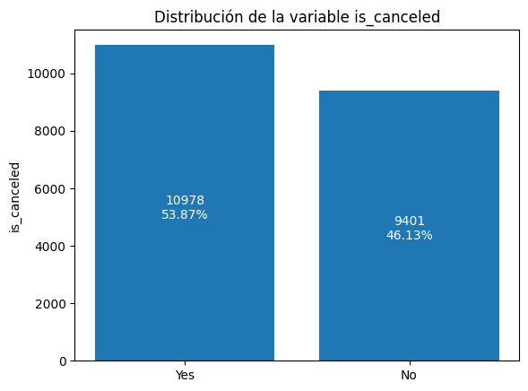

```python
fig = distribucion_variable_predecir(df, "is_canceled")
plt.show()
```

### **Poder Predictivo**

#### Variables Numéricas

```python
# lead_time, stays_in_weekend_nights, stays_in_week_nights, adults, children, babies, previous_cancellations, previous_bookings_not_canceled, booking_changes, days_in_waiting_list, adr, required_car_parking_spaces, total_of_special_requests
```

```python
def poder_predictivo_numerica(data:pd.DataFrame, var:str, variable_predict:str):
  g = sns.FacetGrid(data, hue = variable_predict, height = 4, aspect = 1.8)
  g = g.map(sns.kdeplot, var, fill = True)
  g = g.add_legend()

  g.set_ylabels("Densidad")

  return(g)
```

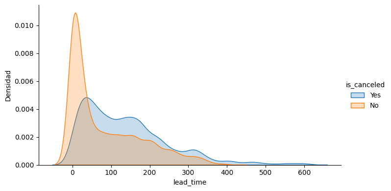

```python
fig = poder_predictivo_numerica(df, "lead_time", "is_canceled")
plt.show()
```

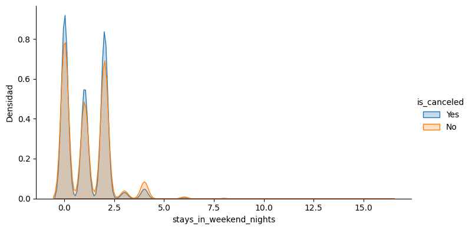

```python
fig = poder_predictivo_numerica(df, "stays_in_weekend_nights", "is_canceled")
plt.show()
```

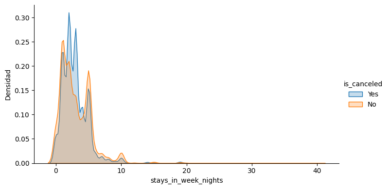

```python
fig = poder_predictivo_numerica(df, "stays_in_week_nights", "is_canceled")
plt.show()
```

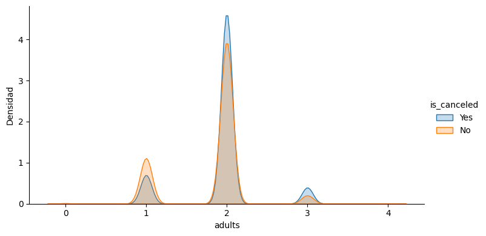

```python
fig = poder_predictivo_numerica(df, "adults", "is_canceled")
plt.show()
```

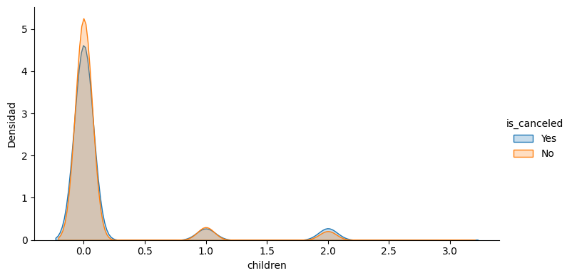

```python
fig = poder_predictivo_numerica(df, "children", "is_canceled")
plt.show()
```

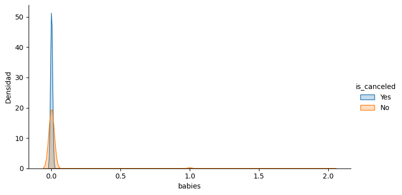

```python
fig = poder_predictivo_numerica(df, "babies", "is_canceled")
plt.show()
```

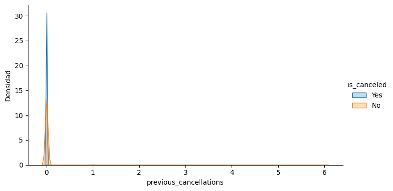

```python
fig = poder_predictivo_numerica(df, "previous_cancellations", "is_canceled")
plt.show()
```

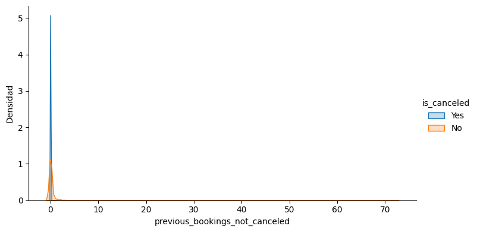

```python
fig = poder_predictivo_numerica(df, "previous_bookings_not_canceled", "is_canceled")
plt.show()
```

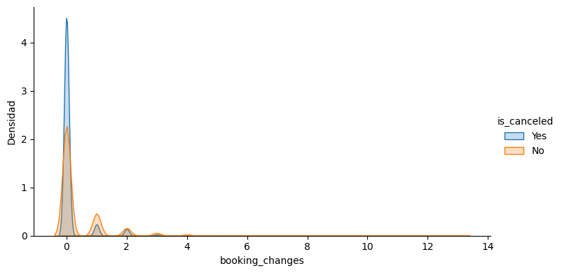

```python
fig = poder_predictivo_numerica(df, "booking_changes", "is_canceled")
plt.show()
```

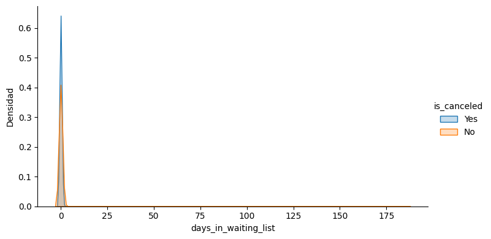

```python
fig = poder_predictivo_numerica(df, "days_in_waiting_list", "is_canceled")
plt.show()
```

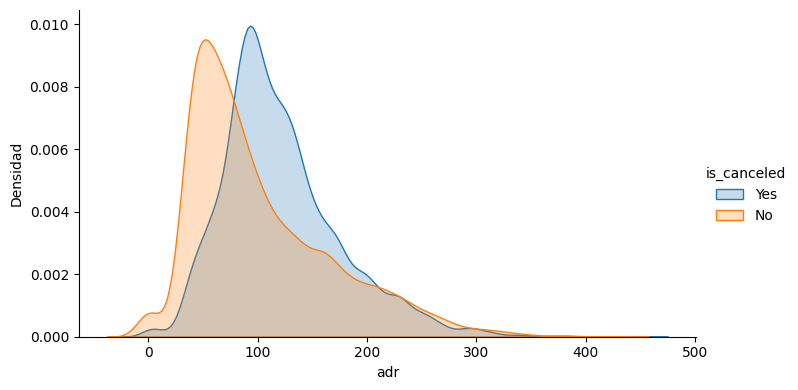

```python
fig = poder_predictivo_numerica(df, "adr", "is_canceled")
plt.show()
```

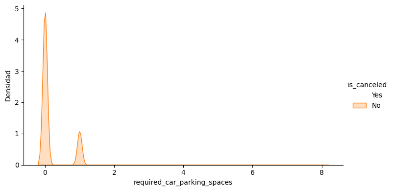

```python
fig = poder_predictivo_numerica(df, "required_car_parking_spaces", "is_canceled")
plt.show()
```

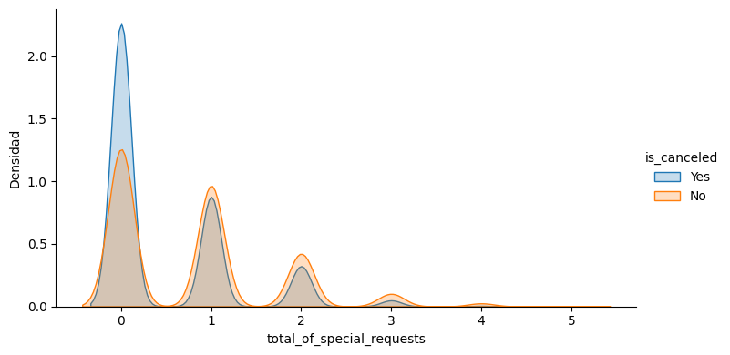

```python
fig = poder_predictivo_numerica(df, "total_of_special_requests", "is_canceled")
plt.show()
```

#### Variables Categoricas

```python
def poder_predictivo_categorica(data: pd.DataFrame, var: str, variable_predict: str):
  titulo = "Distribución de la variable %s según la variable %s" % (var, variable_predict)

  fig, ax = plt.subplots()

  for cat_predictora in data[var].unique():
    conteo     = data.loc[data[var] == cat_predictora, variable_predict].value_counts()
    valores    = conteo.to_numpy()
    categorias = conteo.index.to_numpy()
    porcentaje = valores / sum(valores) * 100
    porcentaje = porcentaje.round(2)

    pos_text = 0
    for i in range(len(porcentaje)):
      if i == 0:
        ax.barh(cat_predictora, porcentaje[i], label=categorias[i], color = plt.cm.tab10(i))
      else:
        ax.barh(cat_predictora, porcentaje[i], left=porcentaje[i-1], label=categorias[i], color = plt.cm.tab10(i))

      ax.text(pos_text + porcentaje[i] / 2, cat_predictora,
              str(porcentaje[i]) + "%\n" + str(valores[i]),
              va='center', ha='center', color='white', fontsize=10)
      pos_text = pos_text + porcentaje[i]

  ax.set_title(titulo)
  handles, labels = ax.get_legend_handles_labels()
  unique = [(h, l) for i, (h, l) in enumerate(zip(handles, labels)) if l not in labels[:i]]
  ax.legend(*zip(*unique), loc = 'upper center', bbox_to_anchor = (1.08, 1))

  return(fig)
```

```python
# hotel, arrival_date_month, assigned_room_type, deposit_type, customer_type
```

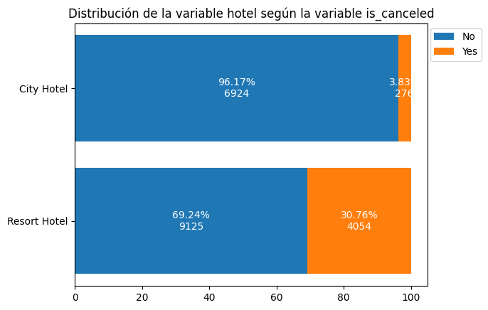

```python
fig = poder_predictivo_categorica(df, "hotel", "is_canceled")
plt.show()
```

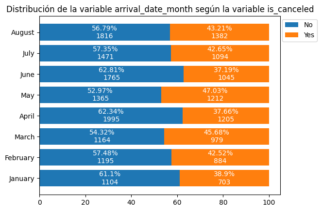

```python
fig = poder_predictivo_categorica(df, "arrival_date_month", "is_canceled")
plt.show()
```

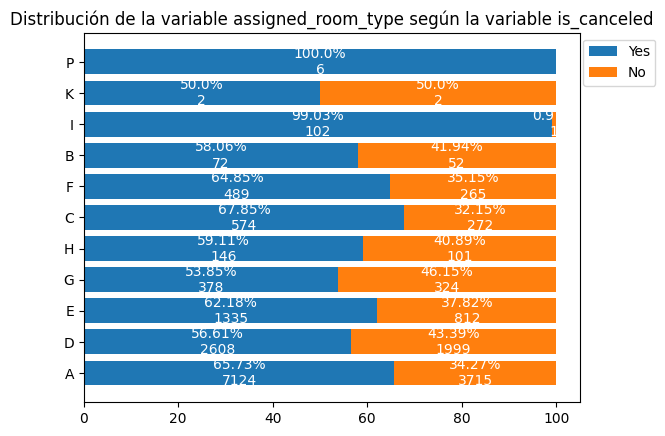

```python
fig = poder_predictivo_categorica(df, "assigned_room_type", "is_canceled")
plt.show()
```

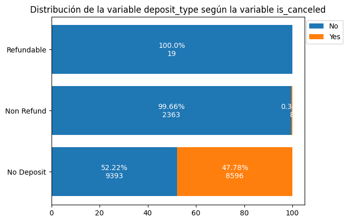

```python
fig = poder_predictivo_categorica(df, "deposit_type", "is_canceled")
plt.show()
```

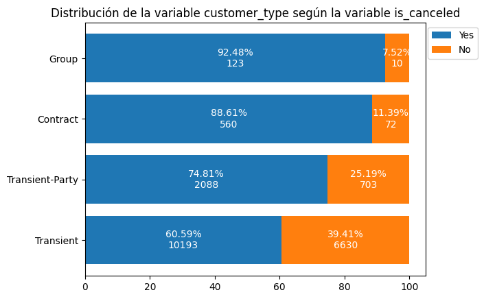

```python
fig = poder_predictivo_categorica(df, "customer_type", "is_canceled")
plt.show()
```

### **Bayes**

**Division Train-Test**

```python
X = df.drop(columns=['is_canceled'])
X.head(2)
```

|  | hotel | lead_time | arrival_date_month | stays_in_weekend_nights | stays_in_week_nights | adults | children | babies | previous_cancellations | previous_bookings_not_canceled | assigned_room_type | booking_changes | deposit_type | days_in_waiting_list | customer_type | adr | required_car_parking_spaces | total_of_special_requests |
| --- | --- | --- | --- | --- | --- | --- | --- | --- | --- | --- | --- | --- | --- | --- | --- | --- | --- | --- |
| 0 | Resort Hotel | 74 | January | 1 | 0 | 2 | 0 | 0 | 0 | 0 | A | 0 | No Deposit | 0 | Transient | 57.6 | 0 | 0 |
| 1 | Resort Hotel | 62 | January | 2 | 2 | 2 | 0 | 0 | 0 | 0 | A | 0 | No Deposit | 0 | Transient | 51.5 | 0 | 1 |

```python
y = df['is_canceled']
y[0:6].to_numpy()
```

```
array(['Yes', 'Yes', 'Yes', 'Yes', 'Yes', 'Yes'], dtype=object)
```

```python
X_train, X_test, y_train, y_test = train_test_split(X, y, test_size=0.10) #90/10
```

**Procesamiento**

```python
var_categoricas = 'hotel', 'arrival_date_month', 'assigned_room_type', 'deposit_type', 'customer_type'
var_numericas = 'lead_time', 'stays_in_weekend_nights', 'stays_in_week_nights', 'adults', 'children', 'babies', 'previous_cancellations', 'previous_bookings_not_canceled', 'booking_changes', 'days_in_waiting_list', 'adr', 'required_car_parking_spaces', 'total_of_special_requests'
```

```python
preprocesamiento = ColumnTransformer(
    transformers=[
        ('cat', OneHotEncoder(sparse_output=False), var_categoricas),
        ('num', StandardScaler(), var_numericas)
    ]
)
```

**Modelado**

Para generar un modelo de `Bayes` se debe utilizar `GaussianNB` del paquete sklearn.

```python
modelo = Pipeline(steps=[
    ('preprocesamiento', preprocesamiento),
    ('clasificador', GaussianNB())
])

modelo.fit(X_train, y_train)
```

```
Pipeline(steps=[('preprocesamiento',
                 ColumnTransformer(transformers=[('cat',
                                                  OneHotEncoder(sparse_output=False),
                                                  ('hotel',
                                                   'arrival_date_month',
                                                   'assigned_room_type',
                                                   'deposit_type',
                                                   'customer_type')),
                                                 ('num', StandardScaler(),
                                                  ('lead_time',
                                                   'stays_in_weekend_nights',
                                                   'stays_in_week_nights',
                                                   'adults', 'children',
                                                   'babies',
                                                   'previous_cancellations',
                                                   'previous_bookings_not_canceled',
                                                   'booking_changes',
                                                   'days_in_waiting_list',
                                                   'adr',
                                                   'required_car_parking_spaces',
                                                   'total_of_special_requests'))])),
                ('clasificador', GaussianNB())])
```

**Predecir**

```python
pred = modelo.predict(X_test)
pred[0:10]
```

```
array(['Yes', 'Yes', 'Yes', 'Yes', 'Yes', 'Yes', 'Yes', 'Yes', 'No',
       'Yes'], dtype='<U3')
```

**Evaluación**

```python
labels = ["Yes", "No"]
MC = confusion_matrix(y_test, pred, labels=labels)
MC
```

```
array([[872, 258],
       [115, 793]])
```

```python
def indices_general(MC, nombres = None):
  precision_global = np.sum(MC.diagonal()) / np.sum(MC)
  error_global     = 1 - precision_global
  precision_categoria  = pd.DataFrame(MC.diagonal()/np.sum(MC,axis = 1)).T
  if nombres!=None:
    precision_categoria.columns = nombres

  return {"Matriz de Confusión":MC,
          "Precisión Global":   round(precision_global * 100, 2),
          "Error Global":       round(error_global * 100, 2),
          "Precisión por categoría":round(precision_categoria * 100, 2)}
```

```python
indices = indices_general(MC, labels)
for k in indices:
    print("\n%s:\n%s"%(k,str(indices[k])))
```

```
Matriz de Confusión:
[[872 258]
 [115 793]]

Precisión Global:
81.7

Error Global:
18.3

Precisión por categoría:
     Yes     No
0  77.17  87.33
```

**Interpretación Bayes**

### **Análisis Discriminante Lineal**

**División Train-Test**

```python
X = df.drop(columns=['is_canceled'])
X.head(2)

y = df["is_canceled"]
print(y[0:6].to_numpy())
```

```
['Yes' 'Yes' 'Yes' 'Yes' 'Yes' 'Yes']
```

```python
X_train, X_test, y_train, y_test = train_test_split(X, y, train_size=0.90)
```

**Preprocesamiento**

```python
preprocesamiento = ColumnTransformer(
    transformers=[
        ('cat', OneHotEncoder(sparse_output=False), var_categoricas),
        ('num', StandardScaler(), var_numericas)
    ]
)
```

**Modelado**

Para generar un modelo de Análisis Discriminante Lineal se debe utilizar `LinearDiscriminantAnalysis` del paquete sklearn, algunos de sus parámetros más importantes a destacar son:

- `solver`: Define el método matemático para resolver el modelo. Puede ser: `svd`, `lsqr` o `eigen`.
- `shrinkage`: Aplica regularización a la matriz de covarianza para evitar sobreajuste o inestabilidad. Solo si el parámetro `solver` es `lsqr` o `eigen`. Se puede utilizar `None` (no aplica regularización), `auto` (ajusta automáticamente la regularización) o se puede ajustar maualmente utilizando un valor entre 0 y 1.

```python
modelo = Pipeline(steps=[
    ('preprocesamiento', preprocesamiento),
    ('clasificador', LinearDiscriminantAnalysis(solver='lsqr', shrinkage='auto'))
])

modelo.fit(X_train, y_train)
```

```
Pipeline(steps=[('preprocesamiento',
                 ColumnTransformer(transformers=[('cat',
                                                  OneHotEncoder(sparse_output=False),
                                                  ('hotel',
                                                   'arrival_date_month',
                                                   'assigned_room_type',
                                                   'deposit_type',
                                                   'customer_type')),
                                                 ('num', StandardScaler(),
                                                  ('lead_time',
                                                   'stays_in_weekend_nights',
                                                   'stays_in_week_nights',
                                                   'adults', 'children',
                                                   'babies',
                                                   'previous_cancellations',
                                                   'previous_bookings_not_canceled',
                                                   'booking_changes',
                                                   'days_in_waiting_list',
                                                   'adr',
                                                   'required_car_parking_spaces',
                                                   'total_of_special_requests'))])),
                ('clasificador',
                 LinearDiscriminantAnalysis(shrinkage='auto', solver='lsqr'))])
```

**Predecir**

```python
pred = modelo.predict(X_test)
pred[0:10]
```

```
array(['Yes', 'No', 'No', 'No', 'No', 'Yes', 'No', 'Yes', 'Yes', 'Yes'],
      dtype='<U3')
```

**Evaluacion**

```python
labels = ["Yes", "No"]
MC = confusion_matrix(y_test, pred, labels=labels)
MC
```

```
array([[801, 271],
       [ 89, 877]])
```

```python
indices = indices_general(MC, labels)
for k in indices:
  print("\n%s:\n%s"%(k,str(indices[k])))
```

```
Matriz de Confusión:
[[801 271]
 [ 89 877]]

Precisión Global:
82.34

Error Global:
17.66

Precisión por categoría:
     Yes     No
0  74.72  90.79
```

**Interpretación Análisis Discriminante Lineal**

En comparación con Bayes este modelo tiene mejor precision y error global

### **Análisis Discriminante Cuadrático**

**División Train-Test**

```python
X = df.drop(columns=['is_canceled'])
X.head(2)

y = df["is_canceled"]
print(y[0:6].to_numpy())
```

```
['Yes' 'Yes' 'Yes' 'Yes' 'Yes' 'Yes']
```

```python
X_train, X_test, y_train, y_test = train_test_split(X, y, train_size=0.90)
```

**Preprocesamiento**

```python
preprocesamiento = ColumnTransformer(
    transformers=[
        ('cat', OneHotEncoder(sparse_output=False), var_categoricas),
        ('num', StandardScaler(), var_numericas)
    ]
)
```

**Modelado**

Para generar un modelo de Análisis Discriminante Cuadrático se debe utilizar `QuadraticDiscriminantAnalysis` del paquete sklearn, algunos de sus parámetros más importantes a destacar son:

- `reg_param`: Aplica regularización a la matriz de covarianza de cada clase. El valor debe ser entre 0 (sin regularización) y 1 (mucha regularización).

```python
modelo = Pipeline(steps=[
    ('preprocesamiento', preprocesamiento),
    ('clasificador', QuadraticDiscriminantAnalysis(reg_param = 0.1))
])

modelo.fit(X_train, y_train)
```

```
Pipeline(steps=[('preprocesamiento',
                 ColumnTransformer(transformers=[('cat',
                                                  OneHotEncoder(sparse_output=False),
                                                  ('hotel',
                                                   'arrival_date_month',
                                                   'assigned_room_type',
                                                   'deposit_type',
                                                   'customer_type')),
                                                 ('num', StandardScaler(),
                                                  ('lead_time',
                                                   'stays_in_weekend_nights',
                                                   'stays_in_week_nights',
                                                   'adults', 'children',
                                                   'babies',
                                                   'previous_cancellations',
                                                   'previous_bookings_not_canceled',
                                                   'booking_changes',
                                                   'days_in_waiting_list',
                                                   'adr',
                                                   'required_car_parking_spaces',
                                                   'total_of_special_requests'))])),
                ('clasificador', QuadraticDiscriminantAnalysis(reg_param=0.1))])
```

**Predecir**

```python
pred = modelo.predict(X_test)
pred[0:10]
```

```
array(['Yes', 'Yes', 'Yes', 'No', 'No', 'Yes', 'Yes', 'Yes', 'No', 'Yes'],
      dtype=object)
```

**Evaluacion**

```python
labels = ["Yes", "No"]
MC = confusion_matrix(y_test, pred, labels=labels)
MC
```

```
array([[1074,   35],
       [ 562,  367]])
```

```python
indices = indices_general(MC, labels)
for k in indices:
  print("\n%s:\n%s"%(k,str(indices[k])))
```

```
Matriz de Confusión:
[[1074   35]
 [ 562  367]]

Precisión Global:
70.71

Error Global:
29.29

Precisión por categoría:
     Yes    No
0  96.84  39.5
```

**Interpretación Análisis Discriminante Cuadrático**

En comparación con Bayes este modelo tiene la peor precision y error global, pero mejor precision por categria en el "Si".  
En comparación con el analisis discriminante lineal, tambien tiene la peor precision y error global, pero mejor precision por categria en el "Si".

## Parte 2

- b) Genere también todos los modelos vistos en cursos anteriores.

```python
def clasification(matriz_confusion):
    VN = matriz_confusion[0][0]
    FP = matriz_confusion[0][1]
    FN = matriz_confusion[1][0]
    VP = matriz_confusion[1][1]

    precision_global = (VN+VP)/(VN+FP+FN+VP)
    error_global = 1 - precision_global
    precision_positiva = VP/(FN+VP)
    precision_negativa = VN/(VN+FP)

    diccionario = {'precision_global ↑': round(precision_global*100, 2),
                    'error_global ↓': round(error_global*100, 2),
                    'precision_positiva ↑': round(precision_positiva*100, 2),
                    'precision_negativa ↑': round(precision_negativa*100, 2)}

    return diccionario
```

Función que facilita la Evaluación de lo Modelos anteriores

```python
def Modelos_Predictivos(X_train, X_test, y_train, y_test, variables_categoricas, variables_numericas, modelo_predictorio, labels):
    preprocesamiento = ColumnTransformer(
        transformers=[
            ('cat', OneHotEncoder(), variables_categoricas),
            ('num', StandardScaler(), variables_numericas)
    ])

    modelo = Pipeline(steps=[
        ('preprocesador', preprocesamiento),
        ('clasificador', modelo_predictorio)
    ])

    modelo.fit(X_train, y_train)
    pred = modelo.predict(X_test)
    #debugiando
    # print(np.unique(y_test))
    # print(np.unique(pred))
    matriz_dtc = confusion_matrix(y_test, pred, labels=labels)

    diccionario = {
        'modelo' : modelo,
        'matriz_confusion' : matriz_dtc
    }

    return diccionario #matriz_dtc
```

### Bayes

- Con el fin de mantener la uniformidad lo volvere a calcular, para mantener el mismo formato.

```python
labels = ["Yes", "No"]
reglas_modelo_bayes = GaussianNB()
modelo_bayes = Modelos_Predictivos(X_train, X_test, y_train, y_test, var_categoricas, var_numericas, reglas_modelo_bayes, labels)

# retorna el value de un key en especfico
modelo_saved_bayes = modelo_bayes.get('modelo')
MC_bayes = modelo_bayes.get('matriz_confusion')

print(f'Matriz de Confusión:\n{MC_bayes}')
bayes_metrics = clasification(MC_bayes) # Guarda un diccionario
bayes_metrics_df = pd.DataFrame(list(bayes_metrics.items()), columns=['Metrics', 'Value'])
bayes_metrics_df['Modelo Predictivo'] = 'Bayes'
bayes_metrics_df
```

```
Matriz de Confusión:
[[836 273]
 [ 97 832]]
```

|  | Metrics | Value | Modelo Predictivo |
| --- | --- | --- | --- |
| 0 | precision_global ↑ | 81.84 | Bayes |
| 1 | error_global ↓ | 18.16 | Bayes |
| 2 | precision_positiva ↑ | 89.56 | Bayes |
| 3 | precision_negativa ↑ | 75.38 | Bayes |

### LinearDiscriminantAnalysis

```python
# labels = ["Yes", "No"]
reglas_modelo_lda = LinearDiscriminantAnalysis(solver='lsqr', shrinkage='auto')
modelo_lda = Modelos_Predictivos(X_train, X_test, y_train, y_test, var_categoricas, var_numericas, reglas_modelo_lda, labels)

# retorna el value de un key en especfico
modelo_saved_lda = modelo_lda.get('modelo')
MC_lda = modelo_lda.get('matriz_confusion')

print(f'Matriz de Confusión:\n{MC_lda}')
lda_metrics = clasification(MC_lda) # Guarda un diccionario
lda_metrics_df = pd.DataFrame(list(lda_metrics.items()), columns=['Metrics', 'Value'])
lda_metrics_df['Modelo Predictivo'] = 'Linear Discriminant Analysis'
lda_metrics_df
```

```
Matriz de Confusión:
[[824 285]
 [ 83 846]]
```

|  | Metrics | Value | Modelo Predictivo |
| --- | --- | --- | --- |
| 0 | precision_global ↑ | 81.94 | Linear Discriminant Analysis |
| 1 | error_global ↓ | 18.06 | Linear Discriminant Analysis |
| 2 | precision_positiva ↑ | 91.07 | Linear Discriminant Analysis |
| 3 | precision_negativa ↑ | 74.30 | Linear Discriminant Analysis |

### QuadraticDiscriminantAnalysis

```python
# labels = ["Yes", "No"]
reglas_modelo_qda = QuadraticDiscriminantAnalysis(reg_param = 0.1)
modelo_qda = Modelos_Predictivos(X_train, X_test, y_train, y_test, var_categoricas, var_numericas, reglas_modelo_qda, labels)

# retorna el value de un key en especfico
modelo_saved_qda = modelo_qda.get('modelo')
MC_qda = modelo_qda.get('matriz_confusion')

print(f'Matriz de Confusión:\n{MC_qda}')
qda_metrics = clasification(MC_qda) # Guarda un diccionario
qda_metrics_df = pd.DataFrame(list(qda_metrics.items()), columns=['Metrics', 'Value'])
qda_metrics_df['Modelo Predictivo'] = 'Quadratic Discriminant Analysis'
qda_metrics_df
```

```
Matriz de Confusión:
[[1074   35]
 [ 562  367]]
```

|  | Metrics | Value | Modelo Predictivo |
| --- | --- | --- | --- |
| 0 | precision_global ↑ | 70.71 | Quadratic Discriminant Analysis |
| 1 | error_global ↓ | 29.29 | Quadratic Discriminant Analysis |
| 2 | precision_positiva ↑ | 39.50 | Quadratic Discriminant Analysis |
| 3 | precision_negativa ↑ | 96.84 | Quadratic Discriminant Analysis |

### SupportVectorMachine (SVM)

```python
# labels = ["Yes", "No"]
reglas_modelo_svm = SVC(kernel='rbf', C=15)
modelo_svm = Modelos_Predictivos(X_train, X_test, y_train, y_test, var_categoricas, var_numericas, reglas_modelo_svm, labels)

# retorna el value de un key en especfico
modelo_saved_svm = modelo_svm.get('modelo')
MC_svm = modelo_svm.get('matriz_confusion')

print(f'Matriz de Confusión:\n{MC_svm}')
svm_metrics = clasification(MC_svm) # Guarda un diccionario
svm_metrics_df = pd.DataFrame(list(svm_metrics.items()), columns=['Metrics', 'Value'])
svm_metrics_df['Modelo Predictivo'] = 'SVM'
svm_metrics_df
```

```
Matriz de Confusión:
[[939 170]
 [106 823]]
```

|  | Metrics | Value | Modelo Predictivo |
| --- | --- | --- | --- |
| 0 | precision_global ↑ | 86.46 | SVM |
| 1 | error_global ↓ | 13.54 | SVM |
| 2 | precision_positiva ↑ | 88.59 | SVM |
| 3 | precision_negativa ↑ | 84.67 | SVM |

### DecisionTreeClassifier

```python
reglas_modelo_dtc = DecisionTreeClassifier(criterion='gini', max_depth=10, min_samples_split=10, min_samples_leaf=10)
modelo_dtc = Modelos_Predictivos(X_train, X_test, y_train, y_test, var_categoricas, var_numericas, reglas_modelo_dtc, labels)

# retorna el value de un key en especfico
modelo_saved_dtc = modelo_dtc.get('modelo')
MC_dtc = modelo_dtc.get('matriz_confusion')

print(f'Matriz de Confusión:\n{MC_dtc}')
dtc_metrics = clasification(MC_dtc) # Guarda un diccionario
dtc_metrics_df = pd.DataFrame(list(dtc_metrics.items()), columns=['Metrics', 'Value'])
dtc_metrics_df['Modelo Predictivo'] = 'DecisionTreeClassifier'
dtc_metrics_df
```

```
Matriz de Confusión:
[[937 172]
 [141 788]]
```

|  | Metrics | Value | Modelo Predictivo |
| --- | --- | --- | --- |
| 0 | precision_global ↑ | 84.64 | DecisionTreeClassifier |
| 1 | error_global ↓ | 15.36 | DecisionTreeClassifier |
| 2 | precision_positiva ↑ | 84.82 | DecisionTreeClassifier |
| 3 | precision_negativa ↑ | 84.49 | DecisionTreeClassifier |

### KNeighborsClassifier

```python
from sklearn.preprocessing import LabelEncoder

codificacion = LabelEncoder()
X_w_cod = df.drop('is_canceled', axis=1)
y_w_cod = df['is_canceled']
y_w_cod = codificacion.fit_transform(y)

X_w_cod_train, X_w_cod_test, y_w_cod_train, y_w_cod_test = train_test_split(X_w_cod, y_w_cod, train_size=0.90)
```

```python
labels_cod = [0, 1] # No, Yes
reglas_modelo_knn = KNeighborsClassifier(n_neighbors=20, weights='uniform', metric = "canberra")
modelo_knn = Modelos_Predictivos(X_w_cod_train, X_w_cod_test, y_w_cod_train, y_w_cod_test, var_categoricas, var_numericas, reglas_modelo_knn, labels_cod)

# retorna el value de un key en especfico
modelo_saved_knn = modelo_knn.get('modelo')
MC_knn = modelo_knn.get('matriz_confusion')

print(f'Matriz de Confusión:\n{MC_knn}')
knn_metrics = clasification(MC_knn) # Guarda un diccionario
knn_metrics_df = pd.DataFrame(list(knn_metrics.items()), columns=['Metrics', 'Value'])
knn_metrics_df['Modelo Predictivo'] = 'KNeighborsClassifier'
knn_metrics_df
```

```
Matriz de Confusión:
[[791 132]
 [223 892]]
```

|  | Metrics | Value | Modelo Predictivo |
| --- | --- | --- | --- |
| 0 | precision_global ↑ | 82.58 | KNeighborsClassifier |
| 1 | error_global ↓ | 17.42 | KNeighborsClassifier |
| 2 | precision_positiva ↑ | 80.00 | KNeighborsClassifier |
| 3 | precision_negativa ↑ | 85.70 | KNeighborsClassifier |

### RandomForestClassifier

```python
reglas_modelo_rfc = RandomForestClassifier(n_estimators=47, max_features='sqrt', criterion = "log_loss", max_depth=12)
modelo_rfc = Modelos_Predictivos(X_train, X_test, y_train, y_test, var_categoricas, var_numericas, reglas_modelo_rfc, labels)

# retorna el value de un key en especfico
modelo_saved_rfc = modelo_rfc.get('modelo')
MC_rfc = modelo_rfc.get('matriz_confusion')

print(f'Matriz de Confusión:\n{MC_rfc}')
rfc_metrics = clasification(MC_rfc) # Guarda un diccionario
rfc_metrics_df = pd.DataFrame(list(rfc_metrics.items()), columns=['Metrics', 'Value'])
rfc_metrics_df['Modelo Predictivo'] = 'RandomForestClassifier'
rfc_metrics_df
```

```
Matriz de Confusión:
[[896 213]
 [ 76 853]]
```

|  | Metrics | Value | Modelo Predictivo |
| --- | --- | --- | --- |
| 0 | precision_global ↑ | 85.82 | RandomForestClassifier |
| 1 | error_global ↓ | 14.18 | RandomForestClassifier |
| 2 | precision_positiva ↑ | 91.82 | RandomForestClassifier |
| 3 | precision_negativa ↑ | 80.79 | RandomForestClassifier |

### AdaBoostClassifier

```python
reglas_modelo_ab = AdaBoostClassifier(n_estimators=50, learning_rate = 0.1, estimator = DecisionTreeClassifier(max_depth=5))
modelo_ab = Modelos_Predictivos(X_train, X_test, y_train, y_test, var_categoricas, var_numericas, reglas_modelo_ab, labels)

# retorna el value de un key en especfico
modelo_saved_ab = modelo_ab.get('modelo')
MC_ab = modelo_ab.get('matriz_confusion')

print(f'Matriz de Confusión:\n{MC_ab}')
ab_metrics = clasification(MC_ab) # Guarda un diccionario
ab_metrics_df = pd.DataFrame(list(ab_metrics.items()), columns=['Metrics', 'Value'])
ab_metrics_df['Modelo Predictivo'] = 'AdaBoostClassifier'
ab_metrics_df
```

```
Matriz de Confusión:
[[917 192]
 [119 810]]
```

|  | Metrics | Value | Modelo Predictivo |
| --- | --- | --- | --- |
| 0 | precision_global ↑ | 84.74 | AdaBoostClassifier |
| 1 | error_global ↓ | 15.26 | AdaBoostClassifier |
| 2 | precision_positiva ↑ | 87.19 | AdaBoostClassifier |
| 3 | precision_negativa ↑ | 82.69 | AdaBoostClassifier |

### GradientBoostingClassifier

```python
reglas_modelo_gb = GradientBoostingClassifier(n_estimators=28, learning_rate = 0.1, max_features = 'sqrt', max_depth = 5)
modelo_gb = Modelos_Predictivos(X_train, X_test, y_train, y_test, var_categoricas, var_numericas, reglas_modelo_gb, labels)

# retorna el value de un key en especfico
modelo_saved_gb = modelo_gb.get('modelo')
MC_gb = modelo_gb.get('matriz_confusion')

print(f'Matriz de Confusión:\n{MC_gb}')
gb_metrics = clasification(MC_gb) # Guarda un diccionario
gb_metrics_df = pd.DataFrame(list(gb_metrics.items()), columns=['Metrics', 'Value'])
gb_metrics_df['Modelo Predictivo'] = 'GradientBoostingClassifier'
gb_metrics_df
```

```
Matriz de Confusión:
[[892 217]
 [100 829]]
```

|  | Metrics | Value | Modelo Predictivo |
| --- | --- | --- | --- |
| 0 | precision_global ↑ | 84.45 | GradientBoostingClassifier |
| 1 | error_global ↓ | 15.55 | GradientBoostingClassifier |
| 2 | precision_positiva ↑ | 89.24 | GradientBoostingClassifier |
| 3 | precision_negativa ↑ | 80.43 | GradientBoostingClassifier |

### XGBClassifier

```python
# labels_xgb = [0, 1] # No, Yes
reglas_modelo_xb = XGBClassifier(n_estimators = 100, learning_rate = 0.1, max_depth = 5)
modelo_xb = Modelos_Predictivos(X_w_cod_train, X_w_cod_test, y_w_cod_train, y_w_cod_test, var_categoricas, var_numericas, reglas_modelo_xb, labels_cod)

# retorna el value de un key en especfico
modelo_saved_xb = modelo_xb.get('modelo')
MC_xb = modelo_xb.get('matriz_confusion')

print(f'Matriz de Confusión:\n{MC_xb}')
xb_metrics = clasification(MC_xb) # Guarda un diccionario
xb_metrics_df = pd.DataFrame(list(xb_metrics.items()), columns=['Metrics', 'Value'])
xb_metrics_df['Modelo Predictivo'] = 'XGBClassifier'
xb_metrics_df
```

```
Matriz de Confusión:
[[816 107]
 [182 933]]
```

|  | Metrics | Value | Modelo Predictivo |
| --- | --- | --- | --- |
| 0 | precision_global ↑ | 85.82 | XGBClassifier |
| 1 | error_global ↓ | 14.18 | XGBClassifier |
| 2 | precision_positiva ↑ | 83.68 | XGBClassifier |
| 3 | precision_negativa ↑ | 88.41 | XGBClassifier |

## Parte 3

- c) Construya un DataFrame que compare todos los modelos generados. Para esto en cada una de las filas debe aparecer el nombre del modelo predictivo y en las columnas deben aparecer los índices `Precisión Global`, `Error Global`, `Precisión Positiva (PP)` y `Precisión Negativa (PN)`. Cuál de los modelos es mejor para estos datos?

```python
all_metrics = pd.concat([bayes_metrics_df, lda_metrics_df, qda_metrics_df, svm_metrics_df, dtc_metrics_df, knn_metrics_df, rfc_metrics_df, ab_metrics_df, gb_metrics_df, xb_metrics_df])
metrics_pivot = pd.pivot_table(all_metrics, index='Modelo Predictivo', columns=['Metrics'], values='Value', fill_value=0)
metrics_pivot
```

| Metrics Modelo Predictivo | error_global ↓ | precision_global ↑ | precision_negativa ↑ | precision_positiva ↑ |
| --- | --- | --- | --- | --- |
| AdaBoostClassifier | 15.26 | 84.74 | 82.69 | 87.19 |
| Bayes | 18.16 | 81.84 | 75.38 | 89.56 |
| DecisionTreeClassifier | 15.36 | 84.64 | 84.49 | 84.82 |
| GradientBoostingClassifier | 15.55 | 84.45 | 80.43 | 89.24 |
| KNeighborsClassifier | 17.42 | 82.58 | 85.70 | 80.00 |
| Linear Discriminant Analysis | 18.06 | 81.94 | 74.30 | 91.07 |
| Quadratic Discriminant Analysis | 29.29 | 70.71 | 96.84 | 39.50 |
| RandomForestClassifier | 14.18 | 85.82 | 80.79 | 91.82 |
| SVM | 13.54 | 86.46 | 84.67 | 88.59 |
| XGBClassifier | 14.18 | 85.82 | 88.41 | 83.68 |

# Ejercicio 2

[30 puntos] Para la siguiente tabla, suponga que se tiene una nueva fila o registro 11 = (`Mayor`, `Medio`, `Secundaria`, `?`) en la base de datos, prediga (a mano) si el individuo va a comprar o no el producto.

| ID | Edad | Ingresos | Educacion | Compro |
| --- | --- | --- | --- | --- |
| 1 | Joven | Bajo | Secundaria | NO |
| 2 | Adulto | Alto | Universitaria | SI |
| 3 | Joven | Medio | Secundaria | SI |
| 4 | Adulto | Medio | Universitaria | NO |
| 5 | Mayor | Bajo | Secundaria | SI |
| 6 | Joven | Alto | Universitaria | SI |
| 7 | Adulto | Alto | Universitaria | SI |
| 8 | Mayor | Medio | Primaria | NO |
| 9 | Mayor | Alto | Tecnica | SI |
| 10 | Joven | Medio | Secundaria | SI |

↑ Volver al Menú

## Probabilidades

$Psi$ = P(C = SI | `Edad` = `Mayor`, `Ingresos` = `Medio`, `Educacion` = `Secundaria`)  
$Pno$ = P(C = NO | `Edad` = `Mayor`, `Ingresos` = `Medio`, `Educacion` = `Secundaria`)

Si $Psi$ > $Pno$ entonces, el individuo si compra el producto, de lo contrario no lo compra.

$Psi = P(C= SI | X = x) y Pno = P(C = NO | X = x)$, en donde  
$C = Compro, x =$ (`Mayor`, `Medio`, `Secundaria`) y $X$ (`Edad`, `Ingresos`, `Educacion`)

## Cálculos según características para predecir

(P(X = x | C = SI)  
= P(Edad = Mayor | C = SI) = 2/7 *  
= P(Ingresos = Medio | C = SI) = 2/7 *  
= P(Educacion = Secundaria | C = SI) = 3/7)

$P(X = x | C = SI) =$ $\frac{12}{343}$ $= 0.03498$

(P(X = x | C = NO)  
= P(Edad = Mayor | C = NO) = 1/3 *  
= P(Ingresos = Medio | C = NO) = 2/3 *  
= P(Educacion = Secundaria | C = NO) = 1/3)

$P(X = x | C = NO) =$ $\frac{2}{27}$ $= 0.07407$

## Aplicación de la Fórmula de Bayes

$Psi = P(C = SI | X = x)$  
$Psi = (P(X = x | C = SI) * P(C=SI)) / (P(X = x | C = SI) * P(C=SI) + P(X = x | C = NO) * P(C=NO))$

Psi = (12/343 * 7/10) / (12/343 * 7/10 + 2/27 * 3/10)  
**Psi = 0.52441**

$Pno = P(C = NO | X = x)$  
$Pno = (P(X = x | C = NO) * P(C=NO)) / (P(X = x | C = SI) * P(C=SI) + P(X = x | C = NO) * P(C=NO))$

Pno = (2/27 * 3/10) / (12/343 * 7/10 + 2/27 * 3/10)  
**Pno = 0.47580**

## Resultados

- $Psi = 0.52441 > Pno = 0.47580$, **por lo que el individuo `SI` compraría el producto.**

# Ejercicio 3

[30 puntos] Para la siguiente tabla, suponga que se tiene una nueva fila o registro de la base de datos 16 = (`Baja`, `Moderado`, `Básico`, `Femenino`, `?`), prediga (a mano) si el desempeño del empleado corresponde a la clase `Regular`, `Bueno` o `Excelente`.

| ID | Satisfaccion | Experiencia | Formacion | Genero | Desempeño |
| --- | --- | --- | --- | --- | --- |
| 1 | Baja | Poco | Basico | Masculino | Excelente |
| 2 | Media | Moderado | Intermedio | Femenino | Bueno |
| 3 | Alta | Mucho | Avanzado | Masculino | Regular |
| 4 | Alta | Moderado | Avanzado | Femenino | Excelente |
| 5 | Baja | Poco | Intermedio | Masculino | Regular |
| 6 | Media | Poco | Basico | Femenino | Regular |
| 7 | Alta | Mucho | Avanzado | Masculino | Excelente |
| 8 | Baja | Poco | Basico | Femenino | Bueno |
| 9 | Media | Moderado | Intermedio | Masculino | Regular |
| 10 | Alta | Mucho | Avanzado | Femenino | Excelente |
| 11 | Alta | Poco | Intermedio | Femenino | Bueno |
| 12 | Media | Moderado | Avanzado | Femenino | Excelente |
| 13 | Baja | Moderado | Basico | Masculino | Regular |
| 14 | Media | Mucho | Intermedio | Masculino | Bueno |
| 15 | Alta | Moderado | Avanzado | Masculino | Excelente |

↑ Volver al Menú

## Probabilidades

Pe = P(D = Excelente | Satisfaccion = `Baja`, Experiencia = `Moderado`, Formacion = `Basico`, Genero = `Femenino`)  
Pb = P(D = Bueno | Satisfaccion = `Baja`, Experiencia = `Moderado`, Formacion = `Basico`, Genero = `Femenino`)  
Pr = P(D = Regular | Satisfaccion = `Baja`, Experiencia = `Moderado`, Formacion = `Basico`, Genero = `Femenino`)

$Pe = P(D = `Excelente` | X = x)$, $Pb = P(C = Bueno | X = x)$ y $Pr = P(C = Regular | X = x)$, en donde:  
$D = Desempeño, x = ($`Baja`, `Moderado`, `Basico`, `Femenino`$)$ y $X$ (`Satisfaccion`, `Ingresos`, `Formacion`, `Genero`)

## Cálculos segun características para predecir

Para, $Pe = P(D = Excelente | X = x)$

$Pe = P(X = x | D = Excelente) * P(D = Excelente / P(X = x | D = Excelente) * P(D = Excelente) + P(X = x | D = Bueno) * P(D = Bueno) + P(X = x | D = Regular) * P(D = Regular))$

(P(X = x | D = Excelente)  
= P(Satisfaccion = Baja | D = Excelente) = 1/6 *  
= P(Experiencia = Moderado | D = Excelente) = 3/6 *  
= P(Formacion = Basico | D = Excelente) = 1/6 *  
= P(Genero = Femenino | D = Excelente) = 3/6)

$P(X = x | D = Excelente)$ = $\frac{9}{1296}$ $=$ $\frac{1}{144}$ $= 0.00694$

Para, $Pb = P(D = Bueno | X = x)$  
$Pb = (P(X = x | D = Bueno) * P(D = Bueno)) / (P(X = x | D = Excelente) * P(D = Excelente) + P(X = x | D = Bueno) * P(D = Bueno) + P(X = x | D = Regular) * P(D = Regular))$

(P(X = x | D = Bueno)  
= P(Satisfaccion = Baja | D = Bueno) = 1/4 *  
= P(Experiencia = Moderado | D = Bueno) = 1/4 *  
= P(Formacion = Basico | D = Bueno) = 1/4  
= P(Genero = Femenino | D = Bueno) = 3/4)

$P(X = x | D = Bueno) =$ $\frac{3}{256}$ $= 0.01171$

Para, $Pr = P(D = Regular | X = x)$  
$Pb = (P(X = x | D = Regular) * P(D = Regular)) / (P(X = x | D = Excelente) * P(D = Excelente) + P(X = x | D = Bueno) * P(D = Bueno) + P(X = x | D = Regular) * P(D = Regular))$

(P(X = x | D = Regular)  
= P(Satisfaccion = Baja | D = Regular) = 2/5 *  
= P(Experiencia = Moderado | D = Regular) = 2/5 *  
= P(Formacion = Basico | D = Regular) = 2/5  
= P(Genero = Femenino | D = Regular) = 1/5)

$P(X = x | D = Regular) =$ $\frac{8}{625}$ $= 0.0128$

## Aplicación de la Fórmula de Bayes

Pe = (1/144 * 6/15) / (1/144 * 6/15 + 3/256 * 4/15 + 8/625 * 5/15)  
Pe = (1/360) / (3661/360000) = 0.27314

Pb = (6/15 + 3/256) / (1/144 * 6/15 + 3/256 * 4/15 + 8/625 * 5/15)  
Pb = (1/320) / (3661/360000) = 0.30729

Pr = (8/625 * 5/15) / (1/144 * 6/15 + 3/256 * 4/15 + 8/625 * 5/15)  
Pr = (8/1875) / (3661/360000) = 0.41955

## Resultados

**Como** $Pr = 0.41955 > Pb = 0.30729 > Pe = 0.27314$, **el desempeño del empleado seria `Regular` de acuerdo a las carateristicas dadas.**